# Análise de Senhas Numéricas: Revelando Padrões de Comportamento

Frequentemente são noticiados vazamentos de dados de milhões de pessoas na Internet. E-mails, senhas, entre outros dados, são divulgados e até mesmo comercializados na Deep Web.

Recentemente um vazamento ficou conhecido como COMB, um acrônimo para Combination Of Many Breaches, ou combinação de diversas brechas.

Este vazamento inclui credenciais (e-mails e senhas em texto plano) de sites como LinkedIn, Twitter, entre outros. São mais de 40 GB de credenciais, mais de 1 bilhao de e-mails e senhas. Entre eles:

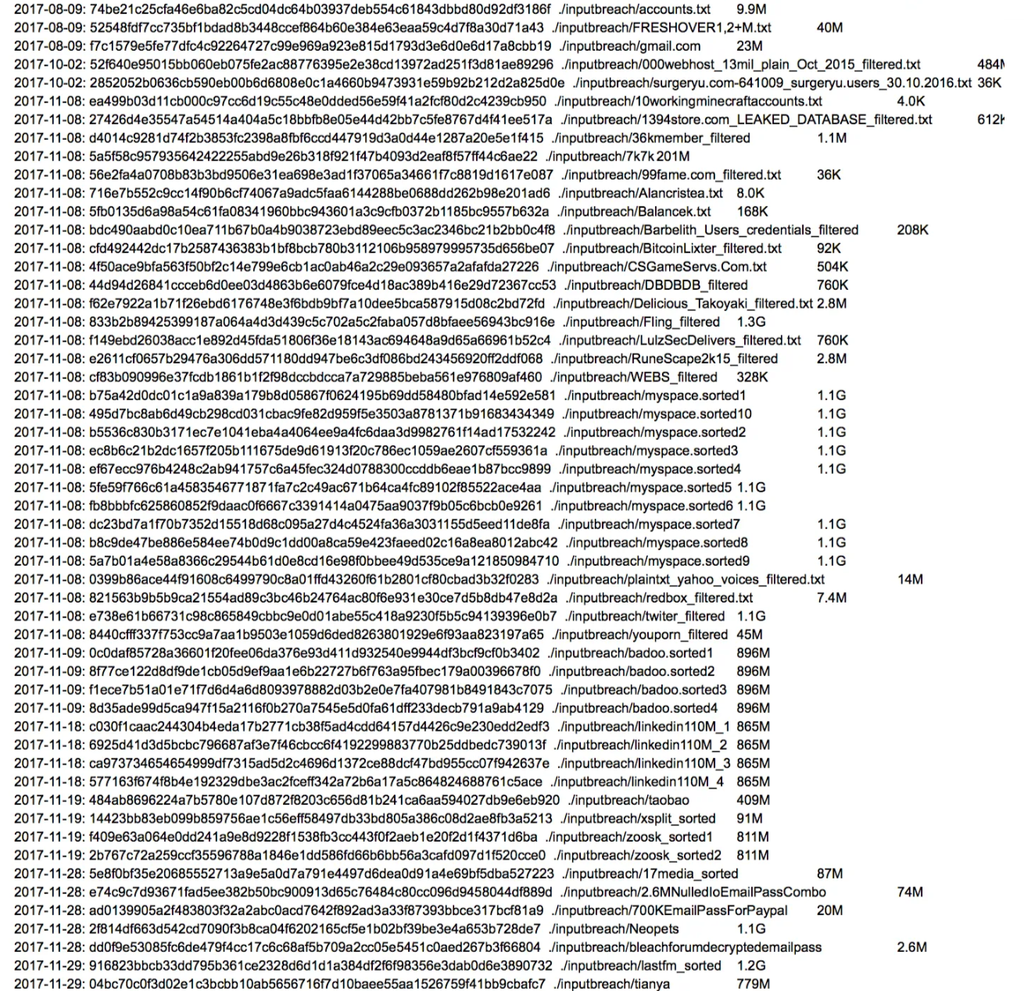

E escopo deste estudo é analisar as senhas numéricas entre 4 e 8 caracteres.

## Importação, Transformação e Persistência

As análises realizadas neste caderno, mesmo tendo uma base com 3 GB, podem passar dos 40 GB de memória RAM, além de demorarem dezenas de minutos em alguns casos.

Deste modo, o estudo foi dividido em diversos notebooks, e cada etapa foi persistida com Pickles, que são mais rápidos que CSVs.

Este notebook inicial tem a função de trabalhar os dados, de modo que as análises posteriores não precisem lidar com passos desnecessários de importação e filtragem.

Para realizar o estudo, após obter as credenciais, foi necessário executar um filtro com expressões regulares para separar apenas as senhas dentro das especificações buscadas, ignorando os e-mails.

```
$ grep -Erao ':[0-9]{4,8}$' data | grep -Eo '^[0-9]{4,8}$' > ~/Desktop/senhas_numericas.txt

$ du -sh senhas_numericas.txt
3.0G    senhas_numericas.txt

$ wc senhas_numericas.txt
417524472  417524472 3183815635 senhas_numericas.txt

$ head -n 20 senhas_numericas.txt
123456
20020326
8910
1212
08737837
087123
1111
12298
010101
129904
55996660
3593081
2273923
590144
844323
844323
000111
8798
123456
19931996
```

O arquivo está pronto para ser importado e analisado, com o apoio de bibliotecas como Pandas, Sklearn, Plotly, entre outras.

```python
import os
import pandas as pd
import pickle
```

```python
%%time

if os.path.exists('senhas_numericas.pickle'):
    print('O arquivo de senhas existe, carregando...')
    with open('senhas_numericas.pickle', 'rb') as file:
        senhas = pickle.load(file)
    print('Importação concluída!\n')
else:
    print('O arquivo de senhas não existe, a importação pode demorar alguns minutos...')
    senhas = pd.read_csv('senhas_numericas.txt', names=['senha'], dtype=str)
    with open('senhas_numericas.pickle', 'wb') as file:
        pickle.dump(senhas, file)
    print('Importação concluída e Pickle exportado com sucesso!\n')

senhas.head(10)
```

```
O arquivo de senhas existe, carregando...
Importação concluída!

CPU times: user 14.8 s, sys: 4.09 s, total: 18.8 s
Wall time: 18.9 s
```

|  | senha |
| --- | --- |
| 0 | 123456 |
| 1 | 20020326 |
| 2 | 8910 |
| 3 | 1212 |
| 4 | 08737837 |
| 5 | 087123 |
| 6 | 1111 |
| 7 | 12298 |
| 8 | 010101 |
| 9 | 129904 |

```python
%%time

senhas.info()
```

```
<class 'pandas.core.frame.DataFrame'>
RangeIndex: 417524472 entries, 0 to 417524471
Data columns (total 1 columns):
 #   Column  Dtype
---  ------  -----
 0   senha   object
dtypes: object(1)
memory usage: 3.1+ GB
CPU times: user 3.65 ms, sys: 0 ns, total: 3.65 ms
Wall time: 3.47 ms
```

```python
%%time

if os.path.exists('descricao.pickle'):
    print('O arquivo de descricao existe, carregando...')
    with open('descricao.pickle', 'rb') as file:
        descricao = pickle.load(file)
    print('Importação concluída!\n')
else:
    print('O arquivo de descricao não existe, a análise pode demorar alguns minutos...')
    descricao = senhas.describe()
    with open('descricao.pickle', 'wb') as file:
        pickle.dump(descricao, file)
    print('Análise concluída e Pickle exportado com sucesso!\n')

descricao
```

```
O arquivo de descricao existe, carregando...
Importação concluída!

CPU times: user 799 µs, sys: 271 µs, total: 1.07 ms
Wall time: 851 µs
```

|  | senha |
| --- | --- |
| count | 417524472 |
| unique | 24140087 |
| top | 123456 |
| freq | 20963035 |

Vamos sumarizar os valores e contar as ocorrências mais frequentes:

**Curiosidade:** durante o processo de contagem, uma média de 14 GB de memória RAM foi consumida na máquina, chegando a picos de 20 GB.

Trabalhar com *checkpoints* agiliza o trabalho de pesquisa nestes casos.

[figure not shown]

```python
%%time

if os.path.exists('contagem_geral.pickle'):
    print('O arquivo de contagem geral existe, carregando...')
    with open('contagem_geral.pickle', 'rb') as file:
        contagem_geral = pickle.load(file)
    print('Importação concluída!\n')
else:
    print('O arquivo de contagem geral não existe, a contagem pode demorar alguns minutos...')
    contagem_geral = pd.DataFrame(senhas['senha'].value_counts(ascending=False).reset_index().values, columns=['senha', 'ocorrencias'])
    contagem_geral['ocorrencias'] = pd.to_numeric(contagem_geral['ocorrencias'])
    contagem_geral['caracteres'] = contagem_geral['senha'].apply(len)
    contagem_geral['caracteres_unicos'] = contagem_geral['senha'].apply(lambda x: len(set(x)))
    total_ocorrencias = contagem_geral['ocorrencias'].sum()
    contagem_geral['ocorrencias_percentuais'] = contagem_geral['ocorrencias'] / total_ocorrencias
    with open('contagem_geral.pickle', 'wb') as file:
        pickle.dump(contagem_geral, file)
    print('Contagem concluída e Pickle exportado com sucesso!\n')
```

```
O arquivo de contagem geral existe, carregando...
Importação concluída!

CPU times: user 1.41 s, sys: 795 ms, total: 2.21 s
Wall time: 2.22 s
```

```python
print('\nTOP 30 senhas numéricas de 4 a 8 dígitos da base analisada:')
contagem_geral.head(30)
```

```
TOP 30 senhas numéricas de 4 a 8 dígitos da base analisada:
```

|  | senha | ocorrencias | caracteres | caracteres_unicos | ocorrencias_percentuais |
| --- | --- | --- | --- | --- | --- |
| 0 | 123456 | 20963035 | 6 | 6 | 0.050208 |
| 1 | 12345 | 7030768 | 5 | 5 | 0.016839 |
| 2 | 12345678 | 3521408 | 8 | 8 | 0.008434 |
| 3 | 111111 | 2906365 | 6 | 1 | 0.006961 |
| 4 | 1234567 | 2363539 | 7 | 7 | 0.005661 |
| 5 | 123123 | 2332470 | 6 | 3 | 0.005586 |
| 6 | 000000 | 1935218 | 6 | 1 | 0.004635 |
| 7 | 123321 | 1447191 | 6 | 3 | 0.003466 |
| 8 | 654321 | 1249387 | 6 | 6 | 0.002992 |
| 9 | 666666 | 1231014 | 6 | 1 | 0.002948 |
| 10 | 1234 | 1230424 | 4 | 4 | 0.002947 |
| 11 | 7777777 | 1055009 | 7 | 1 | 0.002527 |
| 12 | 555555 | 909238 | 6 | 1 | 0.002178 |
| 13 | 121212 | 772307 | 6 | 2 | 0.001850 |
| 14 | 112233 | 689429 | 6 | 3 | 0.001651 |
| 15 | 777777 | 591215 | 6 | 1 | 0.001416 |
| 16 | 159753 | 590989 | 6 | 5 | 0.001415 |
| 17 | 222222 | 520082 | 6 | 1 | 0.001246 |
| 18 | 11111111 | 519894 | 8 | 1 | 0.001245 |
| 19 | 123654 | 464176 | 6 | 6 | 0.001112 |
| 20 | 999999 | 409506 | 6 | 1 | 0.000981 |
| 21 | 1111111 | 396705 | 7 | 1 | 0.000950 |
| 22 | 88888888 | 396317 | 8 | 1 | 0.000949 |
| 23 | 11111 | 371105 | 5 | 1 | 0.000889 |
| 24 | 131313 | 339856 | 6 | 2 | 0.000814 |
| 25 | 1111 | 338337 | 4 | 1 | 0.000810 |
| 26 | 888888 | 331078 | 6 | 1 | 0.000793 |
| 27 | 333333 | 330775 | 6 | 1 | 0.000792 |
| 28 | 1234561 | 329808 | 7 | 6 | 0.000790 |
| 29 | 159357 | 326298 | 6 | 5 | 0.000782 |

O arquivo sumarizado é bem menor que o arquivo inicial, e ainda assim fornece mais informações:

```python
! du -sh *
```

```
37M	Análise.ipynb
3.1M	Carga.ipynb
980M	contagem_geral.pickle
4.0K	descricao.pickle
2.6G	senhas_numericas.pickle
3.0G	senhas_numericas.txt
```